# Bike Sharing Service Analysis and Visualization

### 1. About Bike Sharing Datasets

### 2. Gather the Dataset

#### 2.1 Bay Wheels - The greater San Francisco Bay Area - Data

#### 2.2 Metro Bike Share - Los Angeles - Data

#### 2.3 Capital Bike Share - Washington - Data

### 3. Assess the Datasets

#### 3.1 Data Structuret

#### 3.2 Bay Wheels Dataset Assessment

#### 3.3 Metro Bike Share Dataset Assessment

#### 3.4 Capital Bike Share Dataset Assessment

#### 3.5 Quality Issues

#### 3.6 Tidiness Issues

### 4. Cleaning the Datasets

#### 4.2 Qaulity Issues: Missing values

#### 4.3 Qaulity Issues: Test data in Metro datasett

#### 4.4 Qaulity Issues: Erroneous Data Types of the Variables

#### 4.5 Tidiness Issues

### 5. Store Cleaned Data

### 6. Analyzing and Visualizing - Data Exploration

#### 6.1 Dataset Structure

#### 6.2 Parse and Categorizing

#### 6.3 Bike Demands Analysis

##### 6.3.1 Bike Demands by Day of the Week

##### 6.3.2 Bike Demands by Month

##### 6.3.3 Bike Demands by Time

##### 6.3.4 Bike Demands by Month, Day of the Week and City

#### 6.4 Trip Duration Analysis)

##### 6.4.1Trip Duration

##### 6.4.2 Trip duration on weekdays and weekends

##### 6.4.3 Average Trip Duration of Three Cities

#### 6.5 User Type Analysis

##### 6.5.1 Bike Demands by the Day of the Week

### 6.6 Opinions

#### 6.6.1 About the relationships observed

#### 6.6.2 Require Further Study

# 1. About Bike Sharing Dataset

Data sets include information about individual rides made in a bike-sharing system covering the greater San Francisco Bay area, Los Angeles and Washington DC.

## 1.1 The greater San Francisco Bay Area

- Service name was changed from Ford GoBike to Bay Wheels at May 2019.
- There are 12 files in CSV format and each file has a data of whole month of Year 2019.
- The dataset contains approximately 2.5 million ride information.

## 1.2 Los Angeles

- Service name is Metro Bike Share.
- There are 4 files in CSV formation and each file has a data of quarter of Year 2019.
- The dataset contains approximately 290,000 ride information.

## 1.3 Washington

- Service name is Capital Bike Share.
- There are 12 files in CSV format and each file has a data of whole month of Year 2019.
- The dataset contains approximately 3.4 million ride information.

# 2. Gather the Datasets

```python
# import all packages and set plots to be embedded inline
import numpy as np
import pandas as pd
import matplotlib.pyplot as plt
import seaborn as sb

%matplotlib inline
```

## 2.1 Bay Wheels - The greater San Francisco Bay Area - Data

- The service name was changed at May 2019 from Ford GoBike to Bay Wheels.
- Each file has a riding information for one month.
- Read files and make them into a single dataframe.
- File name format
  - 2019*mm*-fordgobike-tripdata.csv, where *mm*: 01 ~ 04
  - 2019*nn*-baywheels-tripdata.csv, where *nn*: 05 ~ 12

```python
year = '2019'
month = ['01', '02', '03', '04', '05', '06', '07', '08', '09', '10', '11', '12']
```

```python
# read CSV file into pandas DataFrame
file_path = "./data/BayWheels/"
file_list = []
for i in range(4):
    file_name = file_path+year+month[i]+"-fordgobike-tripdata.csv"
    file_list.append(file_name)

for i in range(4, 12):
    file_name = file_path+year+month[i]+"-baywheels-tripdata.csv"
    file_list.append(file_name)

# Concatenate 12 files into one DataFrame
bay_wheels = pd.concat((pd.read_csv(f) for f in file_list), ignore_index=True)
```

## 2.2 Metro Bike Share - Los Angeles - Data

- Each file has a riding information for one quarter.
- Read files and make them into a single dataframe.
- File name format
  - metro-bike-share-trips-2019-q*n*.csv, where *n*: 1 ~ 4

```python
file_path = "./data/Metro_Bike/"
file_list = []
for i in range(1,5):
    file_name = file_path+"metro-bike-share-trips-2019-q"+str(i)+".csv"
    file_list.append(file_name)

# Concatenate 4 files into one DataFrame
metro = pd.concat((pd.read_csv(f) for f in file_list), ignore_index=True)
```

## 2.3 Capital Bike Share - Washington - Data

- Each file has a riding information for one month.
- Read files and make them into a single dataframe.
- File name format
  - 2019*mm*-capitalbikeshare-tripdata.csv, where *mm*: 01 ~ 12

```python
# read CSV file into pandas DataFrame
file_path = "./data/Capital_Bike/"
file_list = []
for i in range(12):
    file_name = file_path+year+month[i]+"-capitalbikeshare-tripdata.csv"
    file_list.append(file_name)

# Concatenate 12 files into one DataFrame
capital = pd.concat((pd.read_csv(f) for f in file_list), ignore_index=True)
```

# 3. Assess the Datasets

## 3.1 Dataset Structure

### 3.1.1 Bay Wheels Data Table

```python
bay_wheels.shape
```

```
(2506983, 15)
```

```python
bay_wheels.info(null_counts=True)
```

```
<class 'pandas.core.frame.DataFrame'>
RangeIndex: 2506983 entries, 0 to 2506982
Data columns (total 15 columns):
 #   Column                   Non-Null Count    Dtype
---  ------                   --------------    -----
 0   duration_sec             2506983 non-null  int64
 1   start_time               2506983 non-null  object
 2   end_time                 2506983 non-null  object
 3   start_station_id         2426249 non-null  float64
 4   start_station_name       2426850 non-null  object
 5   start_station_latitude   2506983 non-null  float64
 6   start_station_longitude  2506983 non-null  float64
 7   end_station_id           2424081 non-null  float64
 8   end_station_name         2424633 non-null  object
 9   end_station_latitude     2506983 non-null  float64
 10  end_station_longitude    2506983 non-null  float64
 11  bike_id                  2506983 non-null  int64
 12  user_type                2506983 non-null  object
 13  bike_share_for_all_trip  2263724 non-null  object
 14  rental_access_method     120838 non-null   object
dtypes: float64(6), int64(2), object(7)
memory usage: 286.9+ MB
```

```python
bay_wheels.head()
```

|  | duration_sec | start_time | end_time | start_station_id | start_station_name | start_station_latitude | start_station_longitude | end_station_id | end_station_name | end_station_latitude | end_station_longitude | bike_id | user_type | bike_share_for_all_trip | rental_access_method |
| --- | --- | --- | --- | --- | --- | --- | --- | --- | --- | --- | --- | --- | --- | --- | --- |
| 0 | 80825 | 2019-01-31 17:57:44.6130 | 2019-02-01 16:24:49.8640 | 229.0 | Foothill Blvd at 42nd Ave | 37.775745 | -122.213037 | 196.0 | Grand Ave at Perkins St | 37.808894 | -122.256460 | 4861 | Subscriber | No | NaN |
| 1 | 65900 | 2019-01-31 20:58:33.8860 | 2019-02-01 15:16:54.1730 | 4.0 | Cyril Magnin St at Ellis St | 37.785881 | -122.408915 | 134.0 | Valencia St at 24th St | 37.752428 | -122.420628 | 5506 | Subscriber | No | NaN |
| 2 | 62633 | 2019-01-31 18:06:52.9240 | 2019-02-01 11:30:46.5300 | 245.0 | Downtown Berkeley BART | 37.870139 | -122.268422 | 157.0 | 65th St at Hollis St | 37.846784 | -122.291376 | 2717 | Customer | No | NaN |
| 3 | 44680 | 2019-01-31 19:46:09.7190 | 2019-02-01 08:10:50.3180 | 85.0 | Church St at Duboce Ave | 37.770083 | -122.429156 | 53.0 | Grove St at Divisadero | 37.775946 | -122.437777 | 4557 | Customer | No | NaN |
| 4 | 60709 | 2019-01-31 14:19:01.5410 | 2019-02-01 07:10:51.0650 | 16.0 | Steuart St at Market St | 37.794130 | -122.394430 | 28.0 | The Embarcadero at Bryant St | 37.787168 | -122.388098 | 2100 | Customer | No | NaN |

### 3.1.2 Metro Bike Share Data Table

```python
metro.shape
```

```
(290342, 15)
```

```python
metro.info()
```

```
<class 'pandas.core.frame.DataFrame'>
RangeIndex: 290342 entries, 0 to 290341
Data columns (total 15 columns):
 #   Column               Non-Null Count   Dtype
---  ------               --------------   -----
 0   trip_id              290342 non-null  int64
 1   duration             290342 non-null  int64
 2   start_time           290342 non-null  object
 3   end_time             290342 non-null  object
 4   start_station        290342 non-null  int64
 5   start_lat            285505 non-null  float64
 6   start_lon            285505 non-null  float64
 7   end_station          290342 non-null  int64
 8   end_lat              279757 non-null  float64
 9   end_lon              279757 non-null  float64
 10  bike_id              290342 non-null  object
 11  plan_duration        290342 non-null  int64
 12  trip_route_category  290342 non-null  object
 13  passholder_type      290342 non-null  object
 14  bike_type            290342 non-null  object
dtypes: float64(4), int64(5), object(6)
memory usage: 33.2+ MB
```

```python
metro.head()
```

|  | trip_id | duration | start_time | end_time | start_station | start_lat | start_lon | end_station | end_lat | end_lon | bike_id | plan_duration | trip_route_category | passholder_type | bike_type |
| --- | --- | --- | --- | --- | --- | --- | --- | --- | --- | --- | --- | --- | --- | --- | --- |
| 0 | 112536773 | 7 | 2019-01-01 00:07:00 | 2019-01-01 00:14:00 | 3046 | 34.052872 | -118.24749 | 3051 | 34.045422 | -118.253517 | 06468 | 1 | One Way | Walk-up | standard |
| 1 | 112536772 | 6 | 2019-01-01 00:08:00 | 2019-01-01 00:14:00 | 3046 | 34.052872 | -118.24749 | 3051 | 34.045422 | -118.253517 | 12311 | 1 | One Way | Walk-up | standard |
| 2 | 112538689 | 32 | 2019-01-01 00:18:00 | 2019-01-01 00:50:00 | 3030 | 34.051941 | -118.24353 | 3075 | 34.042110 | -118.256187 | 05992 | 1 | One Way | Walk-up | standard |
| 3 | 112538688 | 30 | 2019-01-01 00:20:00 | 2019-01-01 00:50:00 | 3030 | 34.051941 | -118.24353 | 3075 | 34.042110 | -118.256187 | 05860 | 1 | One Way | Walk-up | standard |
| 4 | 112538687 | 28 | 2019-01-01 00:22:00 | 2019-01-01 00:50:00 | 3030 | 34.051941 | -118.24353 | 3075 | 34.042110 | -118.256187 | 06006 | 1 | One Way | Walk-up | standard |

### 3.1.3 Capital Bike Share Data Table

```python
capital.shape
```

```
(3398417, 9)
```

```python
capital.info(null_counts=True)
```

```
<class 'pandas.core.frame.DataFrame'>
RangeIndex: 3398417 entries, 0 to 3398416
Data columns (total 9 columns):
 #   Column                Non-Null Count    Dtype
---  ------                --------------    -----
 0   Duration              3398417 non-null  int64
 1   Start date            3398417 non-null  object
 2   End date              3398417 non-null  object
 3   Start station number  3398417 non-null  int64
 4   Start station         3398417 non-null  object
 5   End station number    3398417 non-null  int64
 6   End station           3398417 non-null  object
 7   Bike number           3398403 non-null  object
 8   Member type           3398417 non-null  object
dtypes: int64(3), object(6)
memory usage: 233.4+ MB
```

```python
capital.head()
```

|  | Duration | Start date | End date | Start station number | Start station | End station number | End station | Bike number | Member type |
| --- | --- | --- | --- | --- | --- | --- | --- | --- | --- |
| 0 | 230 | 2019-01-01 00:04:48 | 2019-01-01 00:08:39 | 31203 | 14th & Rhode Island Ave NW | 31200 | Massachusetts Ave & Dupont Circle NW | E00141 | Member |
| 1 | 1549 | 2019-01-01 00:06:37 | 2019-01-01 00:32:27 | 31321 | 15th St & Constitution Ave NW | 31114 | 18th St & Wyoming Ave NW | W24067 | Casual |
| 2 | 177 | 2019-01-01 00:08:46 | 2019-01-01 00:11:44 | 31104 | Adams Mill & Columbia Rd NW | 31323 | Woodley Park Metro / Calvert St & Connecticut ... | W22654 | Casual |
| 3 | 228 | 2019-01-01 00:08:47 | 2019-01-01 00:12:35 | 31281 | 8th & O St NW | 31280 | 11th & S St NW | W22336 | Member |
| 4 | 1300 | 2019-01-01 00:12:29 | 2019-01-01 00:34:10 | 31014 | Lynn & 19th St North | 31923 | Columbia Pike & S Taylor St | 70004 | Member |

### 3.1.4 Summary of Dataset Structure

#### 1) Bay Wheels Datasets

- There are approximately 2.5 million trips in the dataset with 15 features.

| No | column | non-null | type | description |  |
| --- | --- | --- | --- | --- | --- |
| 1 | duration_sec | 2,506,983 | int64 | duration of trip in seconds |  |
| 2 | start_time | 2,506,983 | object | start date and time |  |
| 3 | end_time | 2,506,983 | object | end date and time |  |
| 4 | start_station_id | 2,426,249 | float64 | ID of start station |  |
| 5 | start_station_name | 2,426,850 | object | name of start station |  |
| 6 | start_station_latitude | 2,506,983 | float64 | latitude of start station |  |
| 7 | start_station_longitude | 2,506,983 | float64 | longitude of start station |  |
| 8 | end_station_id | 2,424,081 | float64 | ID of end station |  |
| 9 | end_station_name | 2,424,633 | object | name of end station |  |
| 10 | end_station_latitude | 2,506,983 | float64 | latitude of end station |  |
| 11 | end_station_longitude | 2,506,983 | float64 | longigude of end station |  |
| 12 | bike_id | 2,506,983 | int64 | ID of bike |  |
| 13 | user_type | 2,506,983 | object | Type of user, Subscriber (member) or Customer (temporary) |  |
| 14 | bike_share_for_all_trip | 2,263,724 | object | Yes or No. |  |
| 15 | rental_access_method | 120,838 | object | This feature found in June, July and November. The value is either app or clipper |  |

#### 2) Metro Datasets

- There are approximately 290K trips in the dataset with 15 features.

| No | column | non-null | type | description |
| --- | --- | --- | --- | --- |
| 1 | trip_id | 290,342 | int64 | ID of trip |
| 2 | duration | 290,342 | int64 | length of trip in minutes |
| 3 | start_time | 290,342 | object | start date and time |
| 4 | end_time | 290,342 | object | end date and time |
| 5 | start_station | 290,342 | int64 | start station ID |
| 6 | start_lat | 285,505 | float64 | latitude of start station |
| 7 | start_lon | 285,505 | float64 | longitude of start station |
| 8 | end_station | 290,342 | int64 | end station ID |
| 9 | end_lat | 279,757 | float64 | latitude of end station |
| 10 | end_lon | 279,757 | float64 | longitude of end station |
| 11 | bike_id | 290,342 | object | ID of bike |
| 12 | plan_duration | 290,342 | int64 | The number of days that the plan the passholder is using entitles them to ride; 0 is used for a single ride plan (Walk-up); 999 is used for testing purpose. |
| 13 | trip_route_category | 290,342 | object | Round Trip or One Way |
| 14 | passholder_type | 290,342 | object | The name of the passholder's plan |
| 15 | bike_type | 290,342 | object | The kind of bike used on the trip, including standard pedal-powered bikes, electric assist bikes, or smart bikes. |

#### 3) Capital Datasets

- There are approximately 3.4 million trips in the dataset with 9 features.

[output not shown]

## 3.2 Bay Wheels Dataset Assessment

```python
bay_wheels.duration_sec.describe()
```

```
count    2.506983e+06
mean     8.076483e+02
std      1.974714e+03
min      6.000000e+01
25%      3.590000e+02
50%      5.710000e+02
75%      8.870000e+02
max      9.121100e+05
Name: duration_sec, dtype: float64
```

```python
bay_wheels.start_station_id.value_counts()
```

```
58.0     45058
81.0     42962
30.0     40302
15.0     39016
67.0     36576
         ...
429.0        4
329.0        3
444.0        3
484.0        2
420.0        1
Name: start_station_id, Length: 436, dtype: int64
```

```python
bay_wheels.end_station_id.value_counts()
```

```
67.0     52146
30.0     50943
15.0     48180
21.0     47886
58.0     44284
         ...
428.0        4
444.0        4
484.0        2
329.0        2
65.0         1
Name: end_station_id, Length: 436, dtype: int64
```

```python
bay_wheels.bike_share_for_all_trip.value_counts()
```

```
No     2086152
Yes     177572
Name: bike_share_for_all_trip, dtype: int64
```

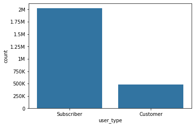

```python
default_color = sb.color_palette()[0]
sb.countplot(data = bay_wheels, x = 'user_type', color = default_color);
y_ticks = np.arange(0, 2100000, 250000)
y_ticks_label = ['0','250K', '500K', '750K', '1M', '1.25M', '1.5M', '1.75M', '2M']
plt.yticks(y_ticks, y_ticks_label);
```

```python
bay_wheels.user_type.value_counts()
```

```
Subscriber    2021166
Customer       485817
Name: user_type, dtype: int64
```

```python
bay_wheels.bike_share_for_all_trip.value_counts()
```

```
No     2086152
Yes     177572
Name: bike_share_for_all_trip, dtype: int64
```

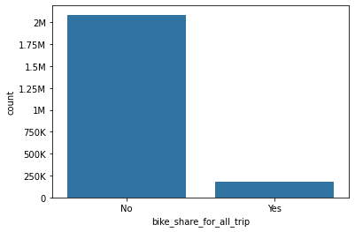

```python
sb.countplot(data = bay_wheels, x = 'bike_share_for_all_trip', color = default_color);
y_ticks = np.arange(0, 2100000, 250000)
y_ticks_label = ['0','250K', '500K', '750K', '1M', '1.25M', '1.5M', '1.75M', '2M']
plt.yticks(y_ticks, y_ticks_label);
```

```python
bay_wheels[bay_wheels.bike_share_for_all_trip == 'Yes'].head()
```

|  | duration_sec | start_time | end_time | start_station_id | start_station_name | start_station_latitude | start_station_longitude | end_station_id | end_station_name | end_station_latitude | end_station_longitude | bike_id | user_type | bike_share_for_all_trip | rental_access_method |
| --- | --- | --- | --- | --- | --- | --- | --- | --- | --- | --- | --- | --- | --- | --- | --- |
| 12 | 272 | 2019-01-31 23:59:44.8800 | 2019-02-01 00:04:17.0800 | 349.0 | Howard St at Mary St | 37.781010 | -122.405666 | 60.0 | 8th St at Ringold St | 37.774520 | -122.409449 | 263 | Subscriber | Yes | NaN |
| 14 | 4310 | 2019-01-31 22:48:47.5180 | 2019-02-01 00:00:37.8000 | 312.0 | San Jose Diridon Station | 37.329732 | -121.901782 | 304.0 | Jackson St at 5th St | 37.348759 | -121.894798 | 3886 | Subscriber | Yes | NaN |
| 16 | 451 | 2019-01-31 23:52:50.1370 | 2019-02-01 00:00:22.1130 | 305.0 | Ryland Park | 37.342725 | -121.895617 | 317.0 | San Salvador St at 9th St | 37.333955 | -121.877349 | 3842 | Subscriber | Yes | NaN |
| 18 | 480 | 2019-01-31 23:48:58.5830 | 2019-01-31 23:56:59.1980 | 370.0 | Jones St at Post St | 37.787327 | -122.413278 | 21.0 | Montgomery St BART Station (Market St at 2nd St) | 37.789625 | -122.400811 | 4960 | Subscriber | Yes | NaN |
| 23 | 424 | 2019-01-31 23:47:30.2110 | 2019-01-31 23:54:34.9960 | 201.0 | 10th St at Fallon St | 37.797673 | -122.262997 | 221.0 | 6th Ave at E 12th St (Temporary Location) | 37.794396 | -122.253842 | 198 | Subscriber | Yes | NaN |

## 3.3 Metro Bike Share Dataset Assessment

```python
metro.duration.describe()
```

```
count    290342.000000
mean         31.080798
std         119.910178
min           1.000000
25%           6.000000
50%          11.000000
75%          22.000000
max        1440.000000
Name: duration, dtype: float64
```

```python
metro.start_station.value_counts()
```

```
3005    14186
3030    13172
3014    10975
3031     8807
4345     7069
        ...
4395       12
4373        3
4327        1
4490        1
4362        1
Name: start_station, Length: 234, dtype: int64
```

```python
metro.end_station.value_counts()
```

```
3005    14892
3014    12164
3030    11535
3031     9263
4345     7171
        ...
4468        3
4362        2
4327        1
4321        1
4490        1
Name: end_station, Length: 237, dtype: int64
```

```python
metro.plan_duration.value_counts()
```

```
30     175457
1       83418
365     31354
999       113
Name: plan_duration, dtype: int64
```

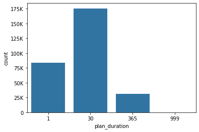

```python
sb.countplot(data = metro, x = 'plan_duration', color = default_color);
y_ticks = np.arange(0, 180000, 25000,)
y_ticks_label = ['0','25K', '50K', '75K', '100K', '125K', '150K', '175K']
plt.yticks(y_ticks, y_ticks_label);
```

```python
metro.passholder_type.value_counts()
```

```
Monthly Pass    172665
Walk-up          80854
Annual Pass      21659
One Day Pass     14731
Flex Pass          320
Testing            113
Name: passholder_type, dtype: int64
```

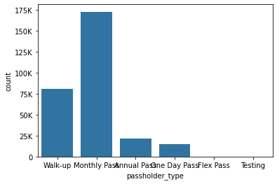

```python
sb.countplot(data = metro, x = 'passholder_type', color = default_color);
y_ticks = np.arange(0, 180000, 25000,)
y_ticks_label = ['0','25K', '50K', '75K', '100K', '125K', '150K', '175K']
plt.yticks(y_ticks, y_ticks_label);
```

```python
metro.bike_type.value_counts()
```

```
standard    154217
electric     96490
smart        39635
Name: bike_type, dtype: int64
```

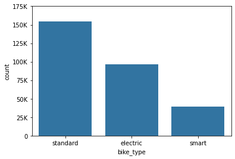

```python
sb.countplot(data = metro, x = 'bike_type', color = default_color);
y_ticks = np.arange(0, 180000, 25000,)
y_ticks_label = ['0','25K', '50K', '75K', '100K', '125K', '150K', '175K']
plt.yticks(y_ticks, y_ticks_label);
```

## 3.4 Capital Bike Share Dataset Assessment

```python
capital.Duration.describe()
```

```
count    3.398417e+06
mean     1.069698e+03
std      2.205485e+03
min      6.000000e+01
25%      3.960000e+02
50%      6.800000e+02
75%      1.152000e+03
max      8.636500e+04
Name: Duration, dtype: float64
```

```python
capital['Start station number'].value_counts()
```

```
31623    58533
31201    35382
31258    35268
31124    34900
31229    34667
         ...
31008       26
31717       21
31824        4
31825        2
31718        1
Name: Start station number, Length: 582, dtype: int64
```

```python
capital['End station number'].value_counts()
```

```
31623    62977
31201    38456
31200    35811
31258    35026
31289    34712
         ...
32419       31
31008       23
31717       18
31824        8
31825        3
Name: End station number, Length: 581, dtype: int64
```

```python
capital['Member type'].value_counts()
```

```
Member    2957256
Casual     441161
Name: Member type, dtype: int64
```

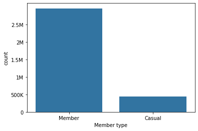

```python
sb.countplot(data = capital, x = 'Member type', color = default_color);
y_ticks = np.arange(0, 3000000, 500000,)
y_ticks_label = ['0','500K', '1M', '1.5M', '2M', '2.5M']
plt.yticks(y_ticks, y_ticks_label);
```

## 3.5 Quality Issues

#### 1) Bay Wheels (formerly Ford GoBike) Table

- start_time and end_time: erroneous data types, should be datetime type
- start_station_id, end_station_id, bike_id: These fields do not require arithmetic operation.
- rental_access_method: 3 out of 12 files have this feature. We can found feature at June, July and November. It should be category type.
- start_station_id: missing values in 80,734 rows
- end_station_id: missing values in 82,902 rows
- user_type: This field is object type (string). Only two kinds of values are possbile. It should be category type.
- bike_share_for_all_trip: 243,259 null values and it should be category type. However, there is no description for this feature. The meaning of this variable is not clear.

#### 2) Metro Bike Share Table

- start_time, end_time: erroneous data types, should be datetime type
- start_station, end_station: erroneous data types, should be string type
- start_lat, start_lon, end_lat, end_lon: missing values
- plan_duration: 999 for test
- passholder_type: object type. It should be categorical type. Value of Testing is not a valid user.
- trip_route_category and bike_type: It should be categorical type.

#### 3) Capital Bike Share Table

- Start date, End date: erroneous data types, should be datetime type
- Start station number and End station number: erroneous data types, should be string type
- Bike number: missing values, 14 rows have null value
- Member type: It should be category type
- column names are not proper to handle. Some of the column names contains space (' ') in their name.

## 3.6 Tidiness Issues

- The number of features and their meaning are different. Washington (Capital Bike Share) dataset has 9 features and the otheer two datasets have 15 features.
  - Common features (meaning or data contains): duration, start time, end time, start station id, end station id, bike id, and user type

# 4. Clean the Datasets

```python
# Copy dataframe for cleaning, do not change anything of original dataframe
bay_wheels_clean = bay_wheels.copy()
metro_clean = metro.copy()
capital_clean = capital.copy()
```

## 4.1 Qaulity Issues: Erroneous column names

#### 1) Define

- column names of the Capital dataset contains space (' ') in their name.
- Make a list of column list
- change space (' ') to underscore ('_') using replace function
- change capital letter to lower letter using lower function

#### 2) Code

```python
# get column names
col = capital_clean.columns
print('old column names: ', col)

# replace space to underscore and capital letter to lower characters
col_names = list(col)
new_col_names = []

for old_name in col_names:
    new_name = old_name.replace(' ', '_')
    new_col_names.append(new_name.lower())

print('new column names: ', new_col_names)
# replace to new column names
capital_clean.columns = new_col_names
```

```
old column names:  Index(['Duration', 'Start date', 'End date', 'Start station number',
       'Start station', 'End station number', 'End station', 'Bike number',
       'Member type'],
      dtype='object')
new column names:  ['duration', 'start_date', 'end_date', 'start_station_number', 'start_station', 'end_station_number', 'end_station', 'bike_number', 'member_type']
```

#### 3) Test

```python
capital_clean.columns
```

```
Index(['duration', 'start_date', 'end_date', 'start_station_number',
       'start_station', 'end_station_number', 'end_station', 'bike_number',
       'member_type'],
      dtype='object')
```

## 4.2 Qaulity Issues: Missing values

#### 1) Define

##### Missing values

- start_station_id and end_station_id from Bay Wheels
- start_lat, start_lon, end_lat, end_lon from Metro
- bike_number from Capital
- for Bay Wheels, drop the rows if start_station_id or end_station_id is null.
- do nothing for the Metro, because coordinates will not use.
- for Capital, drop row if bike_number is null.

#### 2) Code

```python
# bay_wheels_clean dataframe
bay_wheels_clean = bay_wheels_clean[~bay_wheels_clean.start_station_id.isnull()]
bay_wheels_clean = bay_wheels_clean[~bay_wheels_clean.end_station_id.isnull()]

# capital_clean dataframe
capital_clean = capital_clean[~capital_clean.bike_number.isnull()]
```

#### 3) Test

```python
print('bay_wheels_clean: null value count for start_station_id:',
      bay_wheels_clean.start_station_id.isnull().sum())
print('bay_wheels_clean: null value count for end_station_id:',
      bay_wheels_clean.end_station_id.isnull().sum())
print('capital_clean: null value count for bike_number:',
      capital_clean.bike_number.isnull().sum())
print(bay_wheels_clean.info(null_counts=True))
print(capital_clean.info(null_counts=True))
```

```
bay_wheels_clean: null value count for start_station_id: 0
bay_wheels_clean: null value count for end_station_id: 0
capital_clean: null value count for bike_number: 0
<class 'pandas.core.frame.DataFrame'>
Int64Index: 2407259 entries, 0 to 2506660
Data columns (total 15 columns):
 #   Column                   Non-Null Count    Dtype
---  ------                   --------------    -----
 0   duration_sec             2407259 non-null  int64
 1   start_time               2407259 non-null  object
 2   end_time                 2407259 non-null  object
 3   start_station_id         2407259 non-null  float64
 4   start_station_name       2407259 non-null  object
 5   start_station_latitude   2407259 non-null  float64
 6   start_station_longitude  2407259 non-null  float64
 7   end_station_id           2407259 non-null  float64
 8   end_station_name         2407259 non-null  object
 9   end_station_latitude     2407259 non-null  float64
 10  end_station_longitude    2407259 non-null  float64
 11  bike_id                  2407259 non-null  int64
 12  user_type                2407259 non-null  object
 13  bike_share_for_all_trip  2262979 non-null  object
 14  rental_access_method     21859 non-null    object
dtypes: float64(6), int64(2), object(7)
memory usage: 293.9+ MB
None
<class 'pandas.core.frame.DataFrame'>
Int64Index: 3398403 entries, 0 to 3398416
Data columns (total 9 columns):
 #   Column                Non-Null Count    Dtype
---  ------                --------------    -----
 0   duration              3398403 non-null  int64
 1   start_date            3398403 non-null  object
 2   end_date              3398403 non-null  object
 3   start_station_number  3398403 non-null  int64
 4   start_station         3398403 non-null  object
 5   end_station_number    3398403 non-null  int64
 6   end_station           3398403 non-null  object
 7   bike_number           3398403 non-null  object
 8   member_type           3398403 non-null  object
dtypes: int64(3), object(6)
memory usage: 259.3+ MB
None
```

## 4.3 Qaulity Issues: Test data in Metro dataset

#### 1) Define

- Metro dataset has non-user data.
- plan_duration: 999 for test
- passholder_type: Value of 'Testing'
- remove the rows of testing data

#### 2) Code

```python
# metro_clean dataframe
metro_clean.drop(metro_clean.loc[metro_clean.plan_duration == 999].index, inplace=True)
metro_clean.drop(metro_clean.loc[metro_clean.passholder_type == 'Testing'].index, inplace=True)
metro_clean = metro_clean.reset_index(drop=True)
```

#### 3) Test

```python
print('plan duration:', metro_clean.plan_duration.value_counts())
print('passholder_type:', metro_clean.passholder_type.value_counts())
```

```
plan duration: 30     175457
1       83418
365     31354
Name: plan_duration, dtype: int64
passholder_type: Monthly Pass    172665
Walk-up          80854
Annual Pass      21659
One Day Pass     14731
Flex Pass          320
Name: passholder_type, dtype: int64
```

## 4.4 Qaulity Issues: Erroneous Data Types of the Variables

#### 1) Define

##### Date and time features

- start_time and end_time from Bay Wheels: It should be datetime type
- start_time and end_time from Metro: It should be datetime type
- start_date and end_date: It should be datetime type
- Change the data type of above features to datetime type using pandas to_datetime()

##### IDs

- start_station_id, end_station_id and bike_id from Bay Wheels: It should be string type
- start_station and end_station from Metro: It should be string type
- start_station_number and end_station_number from Capital: It should be string type
- Change data type of above features to string using astype() function.
- For Bay Wheels, station id is float type. Values of station id are ended with '.0'. Remove ending '.0' using strip function.

##### User Type

- user_type, bike_share_for_all_trip,and rental_access_method from Bay Wheels: It should be category type.
- trip_route_category, passholder_type, and bike_type from Metro: It should be category type. Value of Testing is not a valid user.
- member_type from Capital: It should be catory type.
- change data type of above features to category type using astype("category").

#### 2) Code

### 4.4.1 Date and time features

```python
# bay_wheels_clean dataframe: start_time and end_time
bay_wheels_clean['start_time'] = pd.to_datetime(bay_wheels_clean['start_time'])
bay_wheels_clean['end_time'] = pd.to_datetime(bay_wheels_clean['end_time'])

# metro_clean dataframe: start_time and end_time
metro_clean['start_time'] = pd.to_datetime(metro_clean['start_time'])
metro_clean['end_time'] = pd.to_datetime(metro_clean['end_time'])

# capital_clean dataframe: Start date and End date
capital_clean['start_date'] = pd.to_datetime(capital_clean['start_date'])
capital_clean['end_date'] = pd.to_datetime(capital_clean['end_date'])
```

### 4.4.2 IDs

```python
# bay_wheels_clean dataframe: start_station_id, end_station_id and bike_id
bay_wheels_clean['start_station_id'] = bay_wheels_clean['start_station_id'].astype(str)
bay_wheels_clean['end_station_id'] = bay_wheels_clean['end_station_id'].astype(str)
bay_wheels_clean['bike_id'] = bay_wheels_clean['bike_id'].astype(str)

# bay_wheels_clean dataframe: remove '.0' in station id
bay_wheels_clean['start_station_id'] = bay_wheels_clean['start_station_id'].str.strip('.0')
bay_wheels_clean['end_station_id'] = bay_wheels_clean['end_station_id'].str.strip('.0')

# metro_clean dataframe: start_station and end_station
metro_clean['start_station'] = metro_clean['start_station'].astype(str)
metro_clean['end_station'] = metro_clean['end_station'].astype(str)

# capital_clean dataframe: start_station_number and end_station_number
capital_clean['start_station_number'] = capital_clean['start_station_number'].astype(str)
capital_clean['end_station_number'] = capital_clean['end_station_number'].astype(str)
```

### 4.4.3 User types

```python
# bay_wheels_clean dataframe: user_type, bike_share_for_all_trip,and rental_access_method
bay_wheels_clean['user_type'] = bay_wheels_clean['user_type'].astype("category")
bay_wheels_clean['bike_share_for_all_trip'] = bay_wheels_clean['bike_share_for_all_trip'].astype("category")
bay_wheels_clean['rental_access_method'] = bay_wheels_clean['rental_access_method'].astype("category")

# metro_clean dataframe: trip_route_category, passholder_type, and bike_type
metro_clean['trip_route_category'] = metro_clean['trip_route_category'].astype("category")
metro_clean['passholder_type'] = metro_clean['passholder_type'].astype("category")
metro_clean['bike_type'] = metro_clean['bike_type'].astype("category")

# capital_clean dataframe: member_type
capital_clean['member_type'] = capital_clean['member_type'].astype("category")
```

#### 3) Test

```python
print(bay_wheels_clean.info(null_counts=True))
print(metro_clean.info())
print(capital_clean.info(null_counts=True))
```

```
<class 'pandas.core.frame.DataFrame'>
Int64Index: 2407259 entries, 0 to 2506660
Data columns (total 15 columns):
 #   Column                   Non-Null Count    Dtype
---  ------                   --------------    -----
 0   duration_sec             2407259 non-null  int64
 1   start_time               2407259 non-null  datetime64[ns]
 2   end_time                 2407259 non-null  datetime64[ns]
 3   start_station_id         2407259 non-null  object
 4   start_station_name       2407259 non-null  object
 5   start_station_latitude   2407259 non-null  float64
 6   start_station_longitude  2407259 non-null  float64
 7   end_station_id           2407259 non-null  object
 8   end_station_name         2407259 non-null  object
 9   end_station_latitude     2407259 non-null  float64
 10  end_station_longitude    2407259 non-null  float64
 11  bike_id                  2407259 non-null  object
 12  user_type                2407259 non-null  category
 13  bike_share_for_all_trip  2262979 non-null  category
 14  rental_access_method     21859 non-null    category
dtypes: category(3), datetime64[ns](2), float64(4), int64(1), object(5)
memory usage: 245.6+ MB
None
<class 'pandas.core.frame.DataFrame'>
RangeIndex: 290229 entries, 0 to 290228
Data columns (total 15 columns):
 #   Column               Non-Null Count   Dtype
---  ------               --------------   -----
 0   trip_id              290229 non-null  int64
 1   duration             290229 non-null  int64
 2   start_time           290229 non-null  datetime64[ns]
 3   end_time             290229 non-null  datetime64[ns]
 4   start_station        290229 non-null  object
 5   start_lat            285444 non-null  float64
 6   start_lon            285444 non-null  float64
 7   end_station          290229 non-null  object
 8   end_lat              279691 non-null  float64
 9   end_lon              279691 non-null  float64
 10  bike_id              290229 non-null  object
 11  plan_duration        290229 non-null  int64
```

[output cut: 8 more lines]

```
Data columns (total 9 columns):
 #   Column                Non-Null Count    Dtype
---  ------                --------------    -----
 0   duration              3398403 non-null  int64
 1   start_date            3398403 non-null  datetime64[ns]
 2   end_date              3398403 non-null  datetime64[ns]
 3   start_station_number  3398403 non-null  object
 4   start_station         3398403 non-null  object
 5   end_station_number    3398403 non-null  object
 6   end_station           3398403 non-null  object
 7   bike_number           3398403 non-null  object
 8   member_type           3398403 non-null  category
dtypes: category(1), datetime64[ns](2), int64(1), object(5)
memory usage: 236.6+ MB
None
```

```python
bay_wheels_clean[['start_station_id', 'end_station_id']].head()
```

|  | start_station_id | end_station_id |
| --- | --- | --- |
| 0 | 229 | 196 |
| 1 | 4 | 134 |
| 2 | 245 | 157 |
| 3 | 85 | 53 |
| 4 | 16 | 28 |

## 4.5 Tidiness Issues

#### 1) Define

- The number of features and their meaning are different. Capital Bike Share dataset has 9 features and the otheer two datasets have 15 features.
  - Common features (meaning or data contains): duration, start time, end time, start station id, end station id, bike id, and user type
- Combine 3 datasets into one dataframe.
- remove unused columns
  - bay_wheels_clean: start_station_name, start_station_latitude, start_station_longitude, end_station_name, end_station_latitude, end_station_longitude, bike_share_for_all_trip, rental_access_method
  - metro_clean: trip_id, start_lat, start_lon, end_lat, end_lon, plan_duration, trip_route_category, bike_type
  - capital_clean: start_station, end_station
- rename column names
  - column names: duration, start_time, end_time, start_station_id, end_station_id, bike_id, user_type
- add city column to distinguish the trip record: San Francisco for Bay Wheels, Los Angeles for Metro and Washington DC for Capital
- merge three dataframes into one dataframe using concat() function

#### 2) Code

```python
# bay_wheels_clean dataframe
# the unit of trip duration in bay_wheels is seconds. Change to the minute
bay_wheels_clean['duration_sec'] = round(bay_wheels_clean['duration_sec'] / 60)
bay_wheels_clean['duration_sec'] = bay_wheels_clean['duration_sec'].astype(int)
remove_col_list = ['start_station_name', 'start_station_latitude', 'start_station_longitude',
                   'end_station_name', 'end_station_latitude', 'end_station_longitude',
                   'bike_share_for_all_trip','rental_access_method']
bay_wheels_clean.drop(remove_col_list, axis = 1, inplace = True)

# metro_clean dataframe
remove_col_list = ['trip_id', 'start_lat', 'start_lon', 'end_lat', 'end_lon',
                   'plan_duration', 'trip_route_category', 'bike_type']
metro_clean.drop(remove_col_list, axis = 1, inplace = True)

# capital_clean dataframe
# the unit of trip duration in bay_wheels is seconds. Change to the minute
capital_clean['duration'] = round(capital_clean['duration'] / 60)
capital_clean['duration'] = capital_clean['duration'].astype(int)
remove_col_list = ['start_station', 'end_station']
capital_clean.drop(remove_col_list, axis = 1, inplace = True)
```

```python
# Change column names
new_col_names = ['duration', 'start_time', 'end_time', 'start_station_id', 'end_station_id', 'bike_id', 'user_type']

# rename bay_wheels_clean dataframe
bay_wheels_clean.columns = new_col_names

# rename metro_clean dataframe
metro_clean.columns = new_col_names

# rename capital_clean dataframe
capital_clean.columns = new_col_names
```

```python
# add one column for identifying city
bay_wheels_clean['city'] = 'San Francisco'
metro_clean['city'] = 'Los Angeles'
capital_clean['city'] = 'Washington DC'
```

```python
# reset index
bay_wheels_clean = bay_wheels_clean.reset_index(drop=True)
metro_clean = metro_clean.reset_index(drop=True)
capital_clean = capital_clean.reset_index(drop=True)
```

```python
# Merge three dataframes into new dataframe named bike_share
bike_share = pd.concat([bay_wheels_clean, metro_clean], ignore_index = True)
bike_share = bike_share.append(capital_clean, ignore_index = True)

# change data type of 'city' column to category
bike_share['user_type'] = bike_share['user_type'].astype("category")
bike_share['city'] = bike_share['city'].astype("category")
```

#### 3) Test

```python
print('bike_share')
print(bike_share.info(null_counts=True))
print('bay_wheels_clean')
print(bay_wheels_clean.info(null_counts=True))
print('metro_clean')
print(metro_clean.info())
print('capital_clean')
print(capital_clean.info(null_counts=True))
```

```
bike_share
<class 'pandas.core.frame.DataFrame'>
RangeIndex: 6095891 entries, 0 to 6095890
Data columns (total 8 columns):
 #   Column            Non-Null Count    Dtype
---  ------            --------------    -----
 0   duration          6095891 non-null  int64
 1   start_time        6095891 non-null  datetime64[ns]
 2   end_time          6095891 non-null  datetime64[ns]
 3   start_station_id  6095891 non-null  object
 4   end_station_id    6095891 non-null  object
 5   bike_id           6095891 non-null  object
 6   user_type         6095891 non-null  category
 7   city              6095891 non-null  category
dtypes: category(2), datetime64[ns](2), int64(1), object(3)
memory usage: 290.7+ MB
None
bay_wheels_clean
<class 'pandas.core.frame.DataFrame'>
RangeIndex: 2407259 entries, 0 to 2407258
Data columns (total 8 columns):
 #   Column            Non-Null Count    Dtype
---  ------            --------------    -----
 0   duration          2407259 non-null  int64
 1   start_time        2407259 non-null  datetime64[ns]
 2   end_time          2407259 non-null  datetime64[ns]
 3   start_station_id  2407259 non-null  object
 4   end_station_id    2407259 non-null  object
 5   bike_id           2407259 non-null  object
 6   user_type         2407259 non-null  category
 7   city              2407259 non-null  object
dtypes: category(1), datetime64[ns](2), int64(1), object(4)
memory usage: 130.9+ MB
None
metro_clean
<class 'pandas.core.frame.DataFrame'>
RangeIndex: 290229 entries, 0 to 290228
Data columns (total 8 columns):
 #   Column            Non-Null Count   Dtype
---  ------            --------------   -----
```

[output cut: 13 more lines]

```
RangeIndex: 3398403 entries, 0 to 3398402
Data columns (total 8 columns):
 #   Column            Non-Null Count    Dtype
---  ------            --------------    -----
 0   duration          3398403 non-null  int64
 1   start_time        3398403 non-null  datetime64[ns]
 2   end_time          3398403 non-null  datetime64[ns]
 3   start_station_id  3398403 non-null  object
 4   end_station_id    3398403 non-null  object
 5   bike_id           3398403 non-null  object
 6   user_type         3398403 non-null  category
 7   city              3398403 non-null  object
dtypes: category(1), datetime64[ns](2), int64(1), object(4)
memory usage: 184.7+ MB
None
```

```python
bike_share.head(10)
```

|  | duration | start_time | end_time | start_station_id | end_station_id | bike_id | user_type | city |
| --- | --- | --- | --- | --- | --- | --- | --- | --- |
| 0 | 1347 | 2019-01-31 17:57:44.613 | 2019-02-01 16:24:49.864 | 229 | 196 | 4861 | Subscriber | San Francisco |
| 1 | 1098 | 2019-01-31 20:58:33.886 | 2019-02-01 15:16:54.173 | 4 | 134 | 5506 | Subscriber | San Francisco |
| 2 | 1044 | 2019-01-31 18:06:52.924 | 2019-02-01 11:30:46.530 | 245 | 157 | 2717 | Customer | San Francisco |
| 3 | 745 | 2019-01-31 19:46:09.719 | 2019-02-01 08:10:50.318 | 85 | 53 | 4557 | Customer | San Francisco |
| 4 | 1012 | 2019-01-31 14:19:01.541 | 2019-02-01 07:10:51.065 | 16 | 28 | 2100 | Customer | San Francisco |
| 5 | 112 | 2019-01-31 22:35:50.813 | 2019-02-01 00:28:04.512 | 245 | 266 | 3532 | Subscriber | San Francisco |
| 6 | 20 | 2019-01-31 23:54:38.901 | 2019-02-01 00:14:27.900 | 34 | 146 | 5114 | Subscriber | San Francisco |
| 7 | 21 | 2019-01-31 23:48:50.092 | 2019-02-01 00:09:44.497 | 318 | 314 | 3967 | Subscriber | San Francisco |
| 8 | 53 | 2019-01-31 23:17:05.462 | 2019-02-01 00:09:39.457 | 29 | 7 | 4813 | Subscriber | San Francisco |
| 9 | 5 | 2019-01-31 23:59:47.568 | 2019-02-01 00:05:11.177 | 223 | 129 | 1976 | Subscriber | San Francisco |

# 5. Store Cleaned Data

```python
# Store bay_wheels_clean dataframe to 'bay_wheels_archive_master.csv'
bay_wheels_clean.to_csv('./data/bay_wheels_archive_master.csv', index=False)

# Store metro_clean dataframe to 'metro_archive_master.csv'
metro_clean.to_csv('./data/metro_archive_master.csv', index=False)

# Store capital_clean dataframe to 'capital_archive_master.csv'
capital_clean.to_csv('./data/capital_archive_master.csv', index=False)

# Store bike_share dataframe to 'bike_share_archive_master.csv'
bike_share.to_csv('./data/bike_share_archive_master.csv', index=False)
```

```python
# remove unused data frames for analysis
del bay_wheels
del metro
del capital

del bay_wheels_clean
del metro_clean
del capital_clean
```

# 6. Analyzing and Visualizing - Data Exploration

## 6.1 Dataset Structure

```python
print(bike_share.shape)
total_case = bike_share.shape[0]
```

```
(6095891, 8)
```

```python
bike_share.info(null_counts=True)
```

```
<class 'pandas.core.frame.DataFrame'>
RangeIndex: 6095891 entries, 0 to 6095890
Data columns (total 8 columns):
 #   Column            Non-Null Count    Dtype
---  ------            --------------    -----
 0   duration          6095891 non-null  int64
 1   start_time        6095891 non-null  datetime64[ns]
 2   end_time          6095891 non-null  datetime64[ns]
 3   start_station_id  6095891 non-null  object
 4   end_station_id    6095891 non-null  object
 5   bike_id           6095891 non-null  object
 6   user_type         6095891 non-null  category
 7   city              6095891 non-null  category
dtypes: category(2), datetime64[ns](2), int64(1), object(3)
memory usage: 290.7+ MB
```

#### Dataset Structure

- Bike share dataset has approximately 6 millions of trip records of three cities with 8 features (duration, start time, end time, start station id, end station id, bike id, user type and city).
- Description of columns

| No | column | non-null | type | description |
| --- | --- | --- | --- | --- |
| 0 | duration | 6,095,891 | int64 | Trip duration in minute |
| 1 | start_time | 6,095,891 | datetime64 | The date/time when the trip began. |
| 2 | end_time | 6,095,891 | datetime64 | The date/time when the trip ended. |
| 3 | start_station_id | 6,095,891 | object | The station ID where the trip originated. |
| 4 | end_station_id | 6,095,891 | object | The station ID where the trip terminated. |
| 5 | bike_id | 6,095,891 | object | bike ID |
| 6 | user_type | 6,095,891 | category | Type of user |
| 7 | city | 6,095,891 | category | San Francisco, Los Angeles, and Washington DC |

#### Main features of interest

- I'm most interested in the following:
  - The relation between bike demand and time, day of week and user type
  - What time is the most demands?
  - What day of the week is the modst demands?
  - What is difference of pattern of demands by user type?

#### Features that support investigation into features of interest

- I expect high demands in the morning time between 7 to 9 on weekday in the downtown area. However, demands on weekends will be different from the demand on weekday.
- The demands of bike will be similar in three cities.

#### Note: The differences in the number of trip information from the three cities are severely different. Especially, the Metro bike share has about 290K cases and it is only 4.8% of the dataset. For this reason, overall trends may mislead the results. To avoid misleading analyses by cities are required.

## 6.2 Parse and Categorizing

### 6.2.1 Parse datetime features: start_time and end_time

- Parse start_time and end_time to month, date, day of the week, hour, and minute
- Add column for indicating working day or not (weekends)

```python
# start_time
bike_share['start_month'] = bike_share['start_time'].dt.month
bike_share['start_date'] = bike_share['start_time'].dt.day
bike_share['start_hour'] = bike_share['start_time'].dt.hour
bike_share['start_minute'] = bike_share['start_time'].dt.minute
bike_share['start_day'] = bike_share['start_time'].dt.day_name()

# end_time
bike_share['end_month'] = bike_share['end_time'].dt.month
bike_share['end_date'] = bike_share['end_time'].dt.day
bike_share['end_hour'] = bike_share['end_time'].dt.hour
bike_share['end_minute'] = bike_share['end_time'].dt.minute
bike_share['end_day'] = bike_share['end_time'].dt.day_name()

# change type of start_day and end_day to category
bike_share['start_day'] = bike_share['start_day'].astype("category")
bike_share['end_day'] = bike_share['end_day'].astype("category")
day_of_week = ['Monday','Tuesday','Wednesday','Thursday','Friday','Saturday', 'Sunday']
bike_share['start_day'] = pd.Categorical(bike_share['start_day'], categories=day_of_week, ordered=True)


# working day or not
work_day_of_week = ['Monday','Tuesday','Wednesday','Thursday','Friday']
bike_share['working_day'] = bike_share['start_day'].isin(work_day_of_week)
bike_share['working_day'] = bike_share['working_day'].astype("category")
```

### 6.2.2 Categorize user_type

- The three bike share services have their own user types. However, the users are categorized by 'Subscriber' and 'Casual' also called 'Customer' user. (It seems casual is more common term rather than customer.)
- Add 'user_category' and assign either 'Subscriber' or 'Casual'

| Service | Area | User Type | User Category |
| --- | --- | --- | --- |
| Bay Wheels | San Francisco | Subscriber | Subscriber |
| Bay Wheels | San Francisco | Customer | Casual |
| Metro Bike Share | Los Angeles | Monthly Pass | Subscriber |
| Metro Bike Share | Los Angeles | Annual Pass | Subscriber |
| Metro Bike Share | Los Angeles | Flex Pass | Subscriber |
| Metro Bike Share | Los Angeles | Walk-up | Casual |
| Metro Bike Share | Los Angeles | One Day Pass | Casual |
| Capital Bike Share | Wasington DC | Member | Subscriber |
| Capital Bike Share | Wasington DC | Casual | Casual |

```python
subscriber = ['Subscriber', 'Monthly Pass', 'Annual Pass', 'Flex Pass', 'Member']
bike_share['user_category'] = bike_share['user_type'].apply(lambda x: 'Subscriber' if x in(subscriber) else 'Casual')
bike_share['user_category'] = bike_share['user_category'].astype("category")
```

```python
bike_share.user_category.value_counts()
```

```
Subscriber    5086930
Casual        1008961
Name: user_category, dtype: int64
```

```python
bike_share.info()
```

```
<class 'pandas.core.frame.DataFrame'>
RangeIndex: 6095891 entries, 0 to 6095890
Data columns (total 20 columns):
 #   Column            Dtype
---  ------            -----
 0   duration          int64
 1   start_time        datetime64[ns]
 2   end_time          datetime64[ns]
 3   start_station_id  object
 4   end_station_id    object
 5   bike_id           object
 6   user_type         category
 7   city              category
 8   start_month       int64
 9   start_date        int64
 10  start_hour        int64
 11  start_minute      int64
 12  start_day         category
 13  end_month         int64
 14  end_date          int64
 15  end_hour          int64
 16  end_minute        int64
 17  end_day           category
 18  working_day       category
 19  user_category     category
dtypes: category(6), datetime64[ns](2), int64(9), object(3)
memory usage: 686.0+ MB
```

```python
bike_share.head()
```

|  | duration | start_time | end_time | start_station_id | end_station_id | bike_id | user_type | city | start_month | start_date | start_hour | start_minute | start_day | end_month | end_date | end_hour | end_minute | end_day | working_day | user_category |
| --- | --- | --- | --- | --- | --- | --- | --- | --- | --- | --- | --- | --- | --- | --- | --- | --- | --- | --- | --- | --- |
| 0 | 1347 | 2019-01-31 17:57:44.613 | 2019-02-01 16:24:49.864 | 229 | 196 | 4861 | Subscriber | San Francisco | 1 | 31 | 17 | 57 | Thursday | 2 | 1 | 16 | 24 | Friday | True | Subscriber |
| 1 | 1098 | 2019-01-31 20:58:33.886 | 2019-02-01 15:16:54.173 | 4 | 134 | 5506 | Subscriber | San Francisco | 1 | 31 | 20 | 58 | Thursday | 2 | 1 | 15 | 16 | Friday | True | Subscriber |
| 2 | 1044 | 2019-01-31 18:06:52.924 | 2019-02-01 11:30:46.530 | 245 | 157 | 2717 | Customer | San Francisco | 1 | 31 | 18 | 6 | Thursday | 2 | 1 | 11 | 30 | Friday | True | Casual |
| 3 | 745 | 2019-01-31 19:46:09.719 | 2019-02-01 08:10:50.318 | 85 | 53 | 4557 | Customer | San Francisco | 1 | 31 | 19 | 46 | Thursday | 2 | 1 | 8 | 10 | Friday | True | Casual |
| 4 | 1012 | 2019-01-31 14:19:01.541 | 2019-02-01 07:10:51.065 | 16 | 28 | 2100 | Customer | San Francisco | 1 | 31 | 14 | 19 | Thursday | 2 | 1 | 7 | 10 | Friday | True | Casual |

## 6.3 Bike Demands Analysis

##### Questions about Bike Demand

- What **day of the week** is the most demand?
- What **time of the day** is the most demand?
- Are the demands different on **weekdays and weekends**?
- Are the demadns different by **month**?
- Are the demands on **day of the week** for the different **months or seasons** similar?
- Does **the weather** affects the demands?
- Are **three cities** of San Francisco, Los Angeles, and Washington DC have **similar pattern of demands**?

### 6.3.1 Demands by day of the week

- Find **what day of the week is the most demand**.

```python
weekday = ['Monday','Tuesday','Wednesday','Thursday','Friday']
weekends = ['Saturday', 'Sunday']
weekday_sum = bike_share.start_day.isin(weekday).sum()
weekends_sum = bike_share.start_day.isin(weekends).sum()

weekday_sum, weekends_sum
```

```
(4706546, 1389345)
```

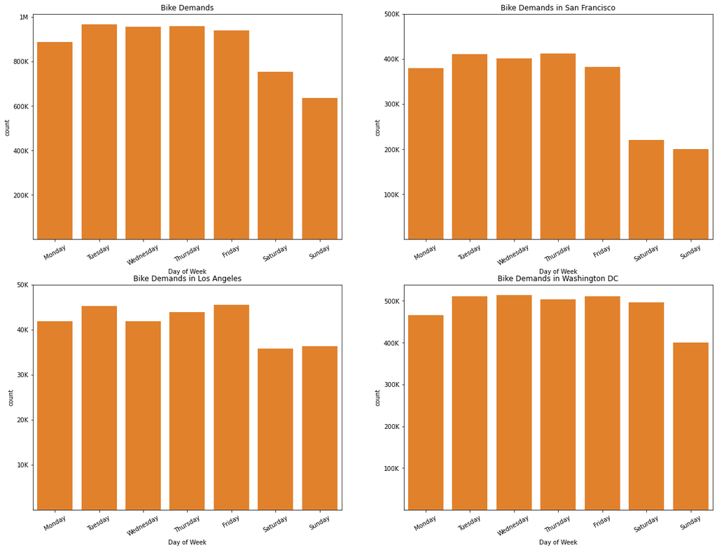

```python
# Plot the demands of bike by day of the week
base_color = sb.color_palette()[1]

# Average demands on weekday and weekend
weekday = ['Monday','Tuesday','Wednesday','Thursday','Friday']
weekends = ['Saturday', 'Sunday']

plt.figure(figsize=[20, 15])

# Bike demands by day of the week.
plt.subplot(2, 2, 1)
g = sb.countplot(data = bike_share, x = 'start_day', color = base_color)
# plt.yscale('log')
y_ticks = [2e5, 4e5, 6e5, 8e5, 10e5]
y_ticks_label = ['200K', '400K','600K','800K', '1M']
plt.yticks(y_ticks, y_ticks_label)
plt.xticks(rotation = '30')
plt.xlabel('Day of Week')
plt.title('Bike Demands');

# compute average demands on weekday and weekend
avg_demand_weekday = bike_share.start_day.isin(weekday).sum()/5
avg_demand_weekends = bike_share.start_day.isin(weekends).sum()/2

# Bike demands by day of the week: San Francisco
plt.subplot(2, 2, 2)
demands = bike_share[bike_share['city'] == 'San Francisco']
g = sb.countplot(data = demands, x = 'start_day', color = base_color)
# plt.yscale('log')
y_ticks = [1e5, 2e5, 3e5, 4e5, 5e5]
y_ticks_label = ['100K', '200K','300K','400K', '500K']
plt.yticks(y_ticks, y_ticks_label)
plt.xticks(rotation = '30')
plt.xlabel('Day of Week')
plt.title('Bike Demands in San Francisco');

# compute average demands on weekday and weekend
avg_demand_weekday_sf = demands.start_day.isin(weekday).sum()/5
avg_demand_weekends_sf = demands.start_day.isin(weekends).sum()/2

# Bike demands by day of the week: Los Angeles
plt.subplot(2, 2, 3)
demands = bike_share[bike_share['city'] == 'Los Angeles']
g = sb.countplot(data = demands, x = 'start_day', color = base_color)
# plt.yscale('log')
y_ticks = [1e4, 2e4, 3e4, 4e4, 5e4]
y_ticks_label = ['10K', '20K','30K','40K', '50K']
plt.yticks(y_ticks, y_ticks_label)
plt.xticks(rotation = '30')
plt.xlabel('Day of Week')
plt.title('Bike Demands in Los Angeles');

# compute average demands on weekday and weekend
avg_demand_weekday_la = demands.start_day.isin(weekday).sum()/5
avg_demand_weekends_la = demands.start_day.isin(weekends).sum()/2

# Bike demands by day of the week: Los Angeles
plt.subplot(2, 2, 4)
demands = bike_share[bike_share['city'] == 'Washington DC']
g = sb.countplot(data = demands, x = 'start_day', color = base_color)
# plt.yscale('log')
y_ticks = [1e5, 2e5, 3e5, 4e5, 5e5]
y_ticks_label = ['100K', '200K','300K','400K', '500K']
plt.yticks(y_ticks, y_ticks_label)
plt.xticks(rotation = '30')
plt.xlabel('Day of Week')
plt.title('Bike Demands in Washington DC');

# compute average demands on weekday and weekend
avg_demand_weekday_dc = demands.start_day.isin(weekday).sum()/5
avg_demand_weekends_dc = demands.start_day.isin(weekends).sum()/2
```

```python
# average demands on weekday and weekends
print('Average Demands (weekday) \t(weekends)')
print('Whole Dataset:\t',avg_demand_weekday,'\t', avg_demand_weekends,'\t',
      '{:.2f}'.format(avg_demand_weekday/avg_demand_weekends))
print('San Francisco:\t', avg_demand_weekday_sf, '\t', avg_demand_weekends_sf,'\t',
      '{:.2f}'.format(avg_demand_weekday_sf/avg_demand_weekends_sf))
print('Los Angeles:\t', avg_demand_weekday_la, '\t', avg_demand_weekends_la,'\t',
      '{:.2f}'.format(avg_demand_weekday_la/avg_demand_weekends_la))
print('Washington DC:\t', avg_demand_weekday_dc,'\t', avg_demand_weekends_dc,'\t',
      '{:.2f}'.format(avg_demand_weekday_dc/avg_demand_weekends_dc))
```

```
Average Demands (weekday) 	(weekends)
Whole Dataset:	 941309.2 	 694672.5 	 1.36
San Francisco:	 397196.4 	 210638.5 	 1.89
Los Angeles:	 43633.6 	 36030.5 	 1.21
Washington DC:	 500479.2 	 448003.5 	 1.12
```

#### Finding (1)

- Average demands on weekdays are higher than on weekends.
- In **San Francisco**, average demands on weekdays are about **1.9 times higher than weekends**.
- In **Los Angeles**, the average demands are **21% more on weekdays**.
- In **Washington DC**, unlike the other two cities, **demands on Sat are similar to weekdays** and a little bit higher than demands on Monday.

### 6.3.2 Bike Demands by Month

- Find **what month is the most demand**.

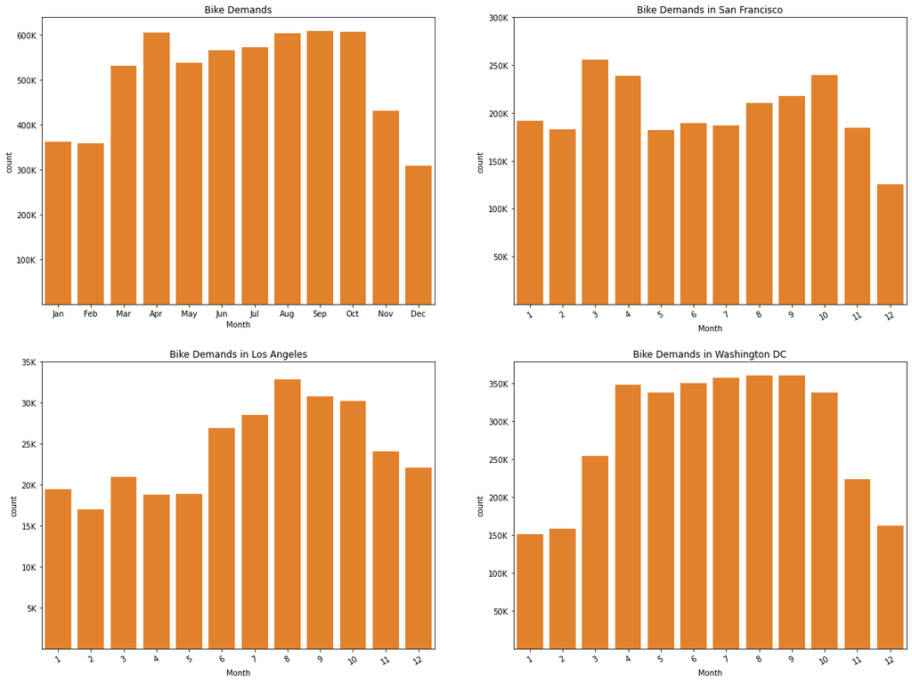

```python
months = ['Jan', 'Feb', 'Mar', 'Apr', 'May', 'Jun', 'Jul', 'Aug', 'Sep', 'Oct', 'Nov', 'Dec']

plt.figure(figsize=[20, 15])

# Bike demands by Month
plt.subplot(2, 2, 1)
g = sb.countplot(data = bike_share, x = 'start_month', color = base_color)
g.set(xticklabels = months)
# plt.yscale('log')
y_ticks = [1e5, 2e5, 3e5, 4e5, 5e5, 6e5]
y_ticks_label = ['100K', '200K','300K','400K', '500K', '600K']
plt.yticks(y_ticks, y_ticks_label)
plt.xlabel('Month')
plt.title('Bike Demands');

# Bike demands by Month: San Francisco
plt.subplot(2, 2, 2)
demands = bike_share[bike_share['city'] == 'San Francisco']
g = sb.countplot(data = demands, x = 'start_month', color = base_color)
# plt.yscale('log')
y_ticks = [0.5e5, 1e5, 1.5e5, 2e5, 2.5e5, 3e5]
y_ticks_label = ['50K', '100K', '150K', '200K','250K','300K']
plt.yticks(y_ticks, y_ticks_label)
plt.xticks(rotation = '30')
plt.xlabel('Month')
plt.title('Bike Demands in San Francisco');

# Bike demands by Month: Los Angeles
plt.subplot(2, 2, 3)
demands = bike_share[bike_share['city'] == 'Los Angeles']
g = sb.countplot(data = demands, x = 'start_month', color = base_color)
# plt.yscale('log')
y_ticks = [0.5e4, 1e4, 1.5e4, 2e4, 2.5e4, 3e4, 3.5e4]
y_ticks_label = ['5K','10K','15K','20K','25K','30K','35K']
plt.yticks(y_ticks, y_ticks_label)
plt.xticks(rotation = '30')
plt.xlabel('Month')
plt.title('Bike Demands in Los Angeles');

# Bike demands by Month: Washington DC
plt.subplot(2, 2, 4)
demands = bike_share[bike_share['city'] == 'Washington DC']
g = sb.countplot(data = demands, x = 'start_month', color = base_color)
# plt.yscale('log')
y_ticks = [0.5e5, 1e5, 1.5e5, 2e5, 2.5e5, 3e5, 3.5e5]
y_ticks_label = ['50K', '100K', '150K', '200K','250K','300K','350K']
plt.yticks(y_ticks, y_ticks_label)
plt.xticks(rotation = '30')
plt.xlabel('Month')
plt.title('Bike Demands in Washington DC');
```

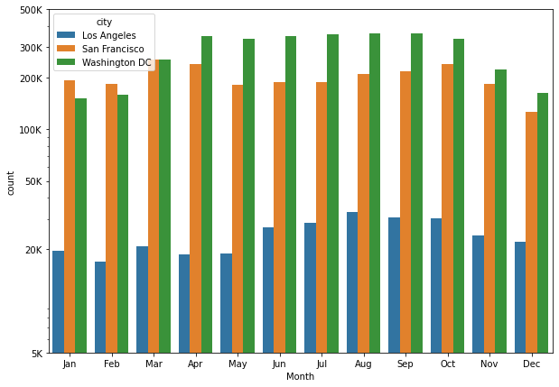

```python
plt.figure(figsize=[10,7])
g = sb.countplot(data = bike_share, x = 'start_month', hue = 'city')
g.set(xticklabels = months)
plt.yscale('log')
y_ticks = [0.5e4, 2e4, 5e4, 1e5, 2e5, 3e5, 5e5]
y_ticks_label = ['5K','20K','50K','100K','200K','300K','500K']
plt.yticks(y_ticks, y_ticks_label)
plt.xlabel('Month');
```

#### Finding (2)

- The plot for the demands by month for the whole dataset shows that the demands drop in the cold-weather seasons from Nov to Feb.
- However, **the demands by cities have different patterns**.
- In **San Francisco**, **the demands from Jan, Feb, May, Jun, July, and Nov are similar**. Dec is the lowest demand month and the highest demand is in Mar.
- In **Los Angeles**, **the demands from Jan to May are similar** and **demands from Nov and Dec are higher than Apr or May**. August is the highest demand, and February is the lowest.
- In **Washington DC**, **high demands from April to October** but, the demands of bikes drop in the winter season. The demands in Washington DC **increased as getting warmer and decrease as getting cold**.
- Further study and more data are needed to understand the demand pattern of the cities.

### 6.3.3 Bike Demands by Time

- Find **what time is the most demand**.
- Is the most demand time different **on weekdays and weekends**?

```python
bike_share_working_day = bike_share[bike_share.working_day == True]
bike_share_non_working_day = bike_share[bike_share.working_day == False]
```

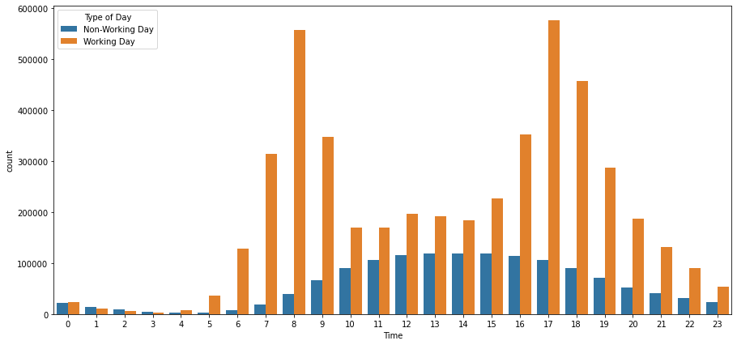

```python
plt.figure(figsize=[15,7])
g = sb.countplot(data = bike_share, x = 'start_hour', hue = 'working_day')
plt.legend(title='Type of Day', loc='upper left', labels=['Non-Working Day', 'Working Day'])
plt.xlabel('Time');
```

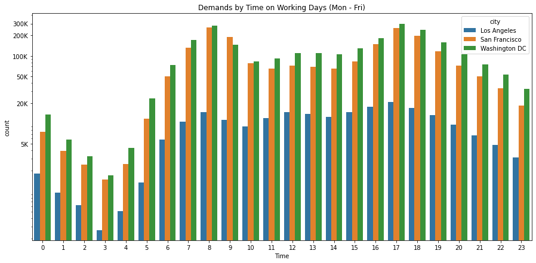

```python
plt.figure(figsize=[15,7])
g = sb.countplot(data = bike_share_working_day, x = 'start_hour', hue = 'city')
plt.yscale('log')
y_ticks = [0.5e4, 2e4, 5e4, 1e5, 2e5, 3e5]
y_ticks_label = ['5K','20K','50K','100K','200K','300K']
plt.yticks(y_ticks, y_ticks_label)
plt.xlabel('Time')
plt.title('Demands by Time on Working Days (Mon - Fri)');
```

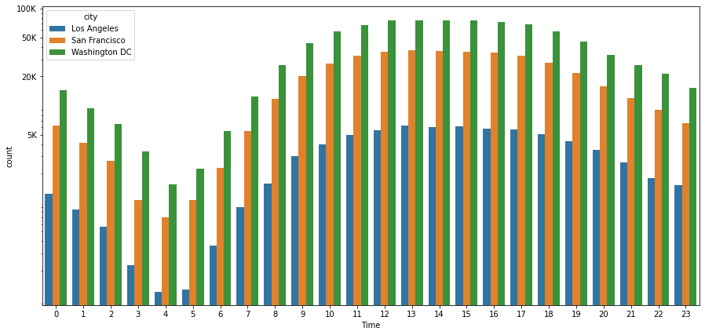

```python
plt.figure(figsize=[15,7])
g = sb.countplot(data = bike_share_non_working_day, x = 'start_hour', hue = 'city')
plt.yscale('log')
y_ticks = [0.5e4, 2e4, 5e4, 1e5]
y_ticks_label = ['5K','20K','50K','100K']
plt.yticks(y_ticks, y_ticks_label)
plt.xlabel('Time');
```

#### Finding (3)

- The pattern of bike demands is quite different between weekdays and weekends.
- The demand patterns by time of the three cities are similar.
- On **weekdays**, more demands on rush hours between **7 to 10 in the morning time** and **16 to 19 in the afternoon**.
- On **weekends**, the demands for bikes peaked in the **daytime between 12 to 16 in the afternoon**.

### 6.3.4 Bike Demands by Month, Day of the Week and City

- Find **bike demands of three cities by month and day of the week**

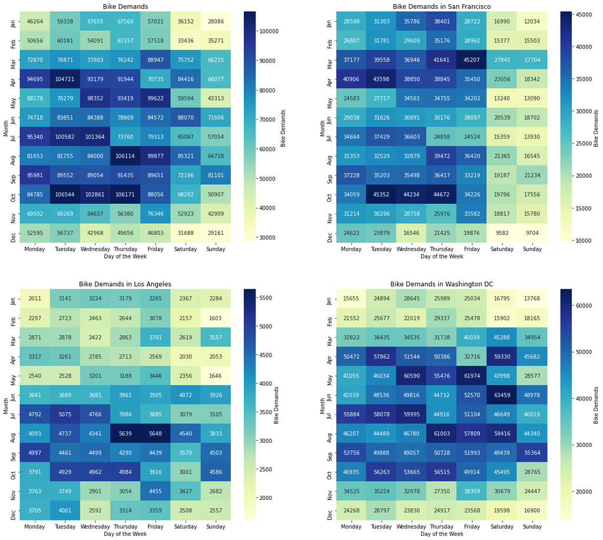

```python
# Demands
# plt.plot([2, 2, 2])
plt.figure(figsize=[20, 18])

# Average Bike Demands: Total
plt.subplot(2, 2, 1)

demands = bike_share.groupby(['start_month','start_day']).count()["bike_id"]
demands = demands.reset_index()
demands = demands.pivot(index = 'start_month', columns = 'start_day', values = 'bike_id')

g = sb.heatmap(demands, annot=True, fmt = 'd', cbar_kws={'label':'Bike Demands'}, cmap = "YlGnBu")
g.set(xticklabels = day_of_week)
g.set(yticklabels = months)

plt.xlabel('Day of the Week')
plt.ylabel('Month')
plt.title("Bike Demands");

# Average Trip Duraion for San Francisco
plt.subplot(2, 2, 2)

demands = bike_share.query('city == "San Francisco"').groupby(['start_month','start_day']).count()["bike_id"]
demands = demands.reset_index()
demands = demands.pivot(index = 'start_month', columns = 'start_day', values = 'bike_id')

g = sb.heatmap(demands, annot=True, fmt = 'd', cbar_kws={'label':'Bike Demands'}, cmap = "YlGnBu")
g.set(xticklabels = day_of_week)
g.set(yticklabels = months)

plt.xlabel('Day of the Week')
plt.ylabel('Month')
plt.title("Bike Demands in San Francisco");

# Average Trip Duraion for Los Angeles
plt.subplot(2, 2, 3)

demands = bike_share.query('city == "Los Angeles"').groupby(['start_month','start_day']).count()["bike_id"]
demands = demands.reset_index()
demands = demands.pivot(index = 'start_month', columns = 'start_day', values = 'bike_id')

g = sb.heatmap(demands, annot=True, fmt = 'd', cbar_kws={'label':'Bike Demands'}, cmap = "YlGnBu")
g.set(xticklabels = day_of_week)
g.set(yticklabels = months)

plt.xlabel('Day of the Week')
plt.ylabel('Month')
plt.title("Bike Demands in Los Angeles");

# Average Trip Duraion for Washington DC
plt.subplot(2, 2, 4)

demands = bike_share.query('city == "Washington DC"').groupby(['start_month','start_day']).count()["bike_id"]
demands = demands.reset_index()
demands = demands.pivot(index = 'start_month', columns = 'start_day', values = 'bike_id')

g = sb.heatmap(demands, annot=True, fmt = 'd', cbar_kws={'label':'Bike Demands'}, cmap = "YlGnBu")
g.set(xticklabels = day_of_week)
g.set(yticklabels = months)

plt.xlabel('Day of the Week')
plt.ylabel('Month')
plt.title("Bike Demands in Washington DC");
```

#### Finding (4)

- The darker colors indicate more rides. The heatmaps show **more rides on weekdays in many months**.
- In **San Francisco**, the bike demands on weekdays are **higher** than on weekends **every month**.
- In **Los Angeles**, the demands on weekends are **similar to or higher than weekdays in Mar, Jun, Aug, and Sep**.
- In **Washington DC**, the demands on weekends are **similar to or higher than weekdays in Mar, Apr, Jun, Jul, Aug, and Sep**.
- In the previous findings on demands by day of the week, the demands on weekends in LA and Washington DC are not many different from weekdays. These plots might explain the reason for previous findings.

## 6.4 Trip Duration Analysis

### 6.4.1 Trip Duration

- Analyze the durations of trips and find **how long time users are using**.

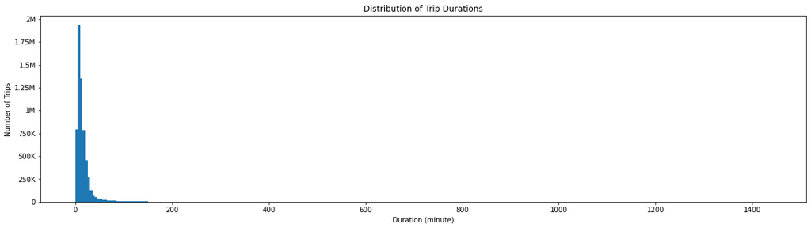

```python
bin_size = 5
bins = np.arange(0, bike_share['duration'].max()+bin_size, bin_size)

plt.figure(figsize=[20,5])
plt.hist(data = bike_share, x = 'duration', bins = bins)
plt.title('Distribution of Trip Durations')
plt.xlabel('Duration (minute)')
y_ticks = [0, 2.5e5, 5e5, 7.5e5, 10e5, 12.5e5, 15e5, 17.5e5, 20e5]
y_ticks_label = ['0', '250K', '500K', '750K', '1M', '1.25M', '1.5M', '1.75M', '2M']
plt.yticks(y_ticks, y_ticks_label)
plt.ylabel('Number of Trips');
```

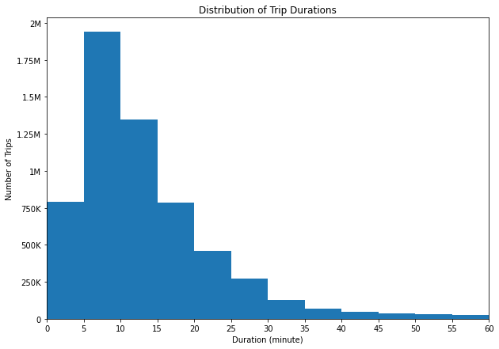

```python
bin_size = 5
bins = np.arange(0, bike_share['duration'].max()+bin_size, bin_size)

plt.figure(figsize=[10,7])
plt.hist(data = bike_share, x = 'duration', bins = bins)

# limit the duration of trip to less than or equal to 60 minutes
plt.xlim(0, 60)
plt.title('Distribution of Trip Durations')
x_ticks = [0, 5, 10, 15, 20, 25, 30, 35, 40, 45, 50, 55, 60]
plt.xticks(x_ticks, x_ticks)
plt.xlabel('Duration (minute)')
y_ticks = [0, 2.5e5, 5e5, 7.5e5, 10e5, 12.5e5, 15e5, 17.5e5, 20e5]
y_ticks_label = ['0', '250K', '500K', '750K', '1M', '1.25M', '1.5M', '1.75M', '2M']
plt.yticks(y_ticks, y_ticks_label)
plt.ylabel('Number of Trips');
```

```python
bike_share.duration.describe()
```

```
count    6.095891e+06
mean     1.671579e+01
std      4.304780e+01
min      1.000000e+00
25%      6.000000e+00
50%      1.000000e+01
75%      1.700000e+01
max      1.440000e+03
Name: duration, dtype: float64
```

- 75% of total trips are less than or equal to 17 minutes.

```python
print('# of trips of less than 5 minutes: ', bike_share[bike_share.duration < 5].duration.count())
print('# of trips of less than 10 minutes: ', bike_share[bike_share.duration < 10].duration.count())
print('# of trips of less than 20 minutes: ', bike_share[bike_share.duration < 20].duration.count())
print('# of trips of less than 30 minutes: ', bike_share[bike_share.duration < 30].duration.count())
print('% of trips of less than 30 minutes: {:.2f}'
      .format((bike_share[bike_share.duration < 30].duration.count()/total_case*100)))
```

```
# of trips of less than 5 minutes:  792581
# of trips of less than 10 minutes:  2731301
# of trips of less than 20 minutes:  4861010
# of trips of less than 30 minutes:  5591765
% of trips of less than 30 minutes: 91.73
```

### 6.4.2 Trip duration on weekdays and weekends

- Find **whether trip duration on weekdays are shorter or not**

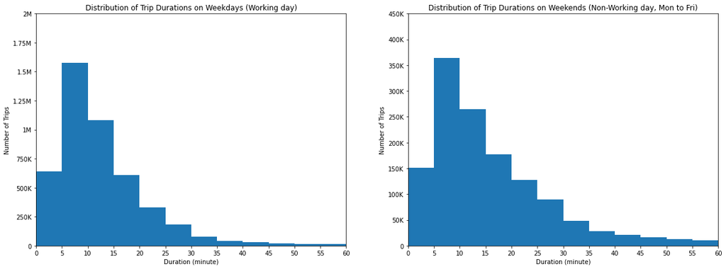

```python
plt.figure(figsize=[20,7])
plt.subplot(1, 2, 1)
plt.hist(data = bike_share_working_day, x = 'duration', bins = bins)

# limit the duration of trip to less than or equal to 60 minutes
plt.xlim(0, 60)
plt.title('Distribution of Trip Durations on Weekdays (Working day)')
x_ticks = [0, 5, 10, 15, 20, 25, 30, 35, 40, 45, 50, 55, 60]
plt.xticks(x_ticks, x_ticks)
plt.xlabel('Duration (minute)')
y_ticks = [0, 2.5e5, 5e5, 7.5e5, 10e5, 12.5e5, 15e5, 17.5e5, 20e5]
y_ticks_label = ['0', '250K', '500K', '750K', '1M', '1.25M', '1.5M', '1.75M', '2M']
plt.yticks(y_ticks, y_ticks_label)
plt.ylabel('Number of Trips');


plt.subplot(1, 2, 2)
plt.hist(data = bike_share_non_working_day, x = 'duration', bins = bins)

# limit the duration of trip to less than or equal to 60 minutes
plt.xlim(0, 60)
plt.title('Distribution of Trip Durations on Weekends (Non-Working day, Mon to Fri)')
x_ticks = [0, 5, 10, 15, 20, 25, 30, 35, 40, 45, 50, 55, 60]
plt.xticks(x_ticks, x_ticks)
plt.xlabel('Duration (minute)')
y_ticks = [0, 5e4, 10e4, 15e4, 20e4, 25e4, 30e4, 35e4, 40e4, 45e4]
y_ticks_label = ['0', '50K', '100K', '150K', '200K', '250K', '300K', '350K', '400K', '450K']
plt.yticks(y_ticks, y_ticks_label)
plt.ylabel('Number of Trips');
```

```python
bike_share_working_day.duration.describe()
```

```
count    4.706546e+06
mean     1.505786e+01
std      3.903237e+01
min      1.000000e+00
25%      6.000000e+00
50%      1.000000e+01
75%      1.600000e+01
max      1.440000e+03
Name: duration, dtype: float64
```

```python
bike_share_non_working_day.duration.describe()
```

```
count    1.389345e+06
mean     2.233220e+01
std      5.411811e+01
min      1.000000e+00
25%      7.000000e+00
50%      1.300000e+01
75%      2.300000e+01
max      1.440000e+03
Name: duration, dtype: float64
```

### 6.4.3 Average Trip Duration of Three Cities

- Find **average trip duration of three cities by month and day of the week**.

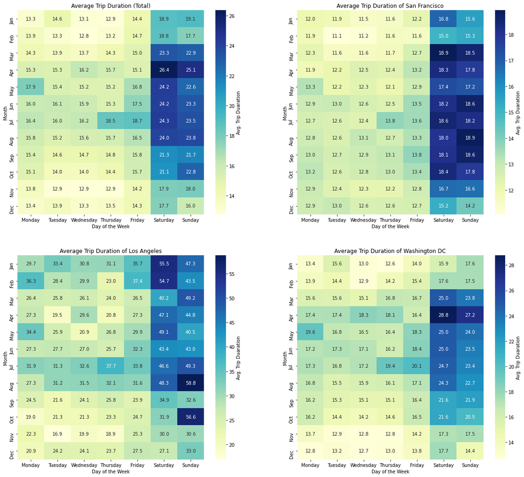

```python
# Average Trip Duration
# plt.plot([2, 2, 2])
plt.figure(figsize=[20, 18])

# Average Trip Duration: Total
plt.subplot(2, 2, 1)

duration_means = bike_share.groupby(['start_month','start_day']).mean()["duration"]
duration_means = duration_means.reset_index()
duration_means = duration_means.pivot(index = 'start_month', columns = 'start_day', values = 'duration')

g = sb.heatmap(duration_means, annot=True, fmt = '.1f', cbar_kws={'label':'Avg. Trip Duaration'}, cmap = "YlGnBu")
g.set(xticklabels = day_of_week)
g.set(yticklabels = months)

plt.xlabel('Day of the Week')
plt.ylabel('Month')
plt.title("Average Trip Duration (Total)");

# Average Trip Duraion for San Francisco
plt.subplot(2, 2, 2)

duration_means = bike_share.query('city == "San Francisco"').groupby(['start_month','start_day']).mean()["duration"]
duration_means = duration_means.reset_index()
duration_means = duration_means.pivot(index = 'start_month', columns = 'start_day', values = 'duration')

g = sb.heatmap(duration_means, annot=True, fmt = '.1f', cbar_kws={'label':'Avg. Trip Duaration'}, cmap = "YlGnBu")
g.set(xticklabels = day_of_week)
g.set(yticklabels = months)

plt.xlabel('Day of the Week')
plt.ylabel('Month')
plt.title("Average Trip Duration of San Francisco");

# Average Trip Duraion for Los Angeles
plt.subplot(2, 2, 3)

duration_means = bike_share.query('city == "Los Angeles"').groupby(['start_month','start_day']).mean()["duration"]
duration_means = duration_means.reset_index()
duration_means = duration_means.pivot(index = 'start_month', columns = 'start_day', values = 'duration')

g = sb.heatmap(duration_means, annot=True, fmt = '.1f', cbar_kws={'label':'Avg. Trip Duaration'}, cmap = "YlGnBu")
g.set(xticklabels = day_of_week)
g.set(yticklabels = months)

plt.xlabel('Day of the Week')
plt.ylabel('Month')
plt.title("Average Trip Duration of Los Angeles");

# Average Trip Duraion for Washington DC
plt.subplot(2, 2, 4)

duration_means = bike_share.query('city == "Washington DC"').groupby(['start_month','start_day']).mean()["duration"]
duration_means = duration_means.reset_index()
duration_means = duration_means.pivot(index = 'start_month', columns = 'start_day', values = 'duration')

g = sb.heatmap(duration_means, annot=True, fmt = '.1f', cbar_kws={'label':'Avg. Trip Duaration'}, cmap = "YlGnBu")
g.set(xticklabels = day_of_week)
g.set(yticklabels = months)

plt.xlabel('Day of the Week')
plt.ylabel('Month')
plt.title("Average Trip Duration of Washington DC");
```

## 6.5 User Type Analysis

- Find **whether casual users are more use bike sharing service on weekends or on weekdays**.

### 6.5.1 Bike Demands by the Day of the Week

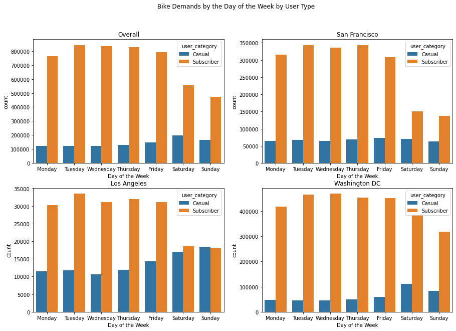

```python
plt.figure(figsize=[15,10])
plt.suptitle('Bike Demands by the Day of the Week by User Type')

plt.subplot(2, 2, 1)
g = sb.countplot(data = bike_share, x = 'start_day', hue = 'user_category')
plt.xlabel('Day of the Week')
plt.title('Overall');

# San Francisco
plt.subplot(2, 2, 2)
demands = bike_share[bike_share.city == "San Francisco"]
g = sb.countplot(data = demands, x = 'start_day', hue = 'user_category')
plt.xlabel('Day of the Week')
plt.title('San Francisco');

# Los Angeles
plt.subplot(2, 2, 3)
demands = bike_share[bike_share.city == "Los Angeles"]
g = sb.countplot(data = demands, x = 'start_day', hue = 'user_category')
plt.xlabel('Day of the Week')
plt.title('Los Angeles');

# Washington DC
plt.subplot(2, 2, 4)
demands = bike_share[bike_share.city == "Washington DC"]
g = sb.countplot(data = demands, x = 'start_day', hue = 'user_category')
plt.xlabel('Day of the Week')
plt.title('Washington DC');
```

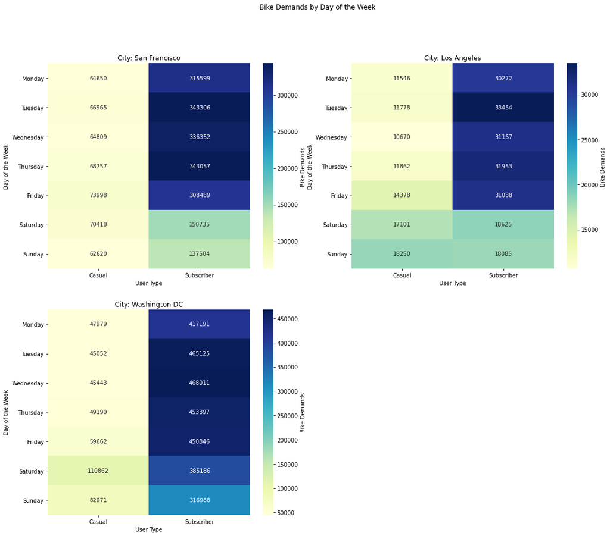

```python
# Average Trip Duraion for San Francisco
plt.figure(figsize=[18,15])
plt.suptitle('Bike Demands by Day of the Week')
plt.subplot(2, 2, 1)

demands = bike_share.query('city == "San Francisco"').groupby(['start_day','user_category']).count()["bike_id"]
demands = demands.reset_index()
demands = demands.pivot(index = 'start_day', columns = 'user_category', values = 'bike_id')

g = sb.heatmap(demands, annot=True, fmt = 'd', cbar_kws={'label':'Bike Demands'}, cmap = "YlGnBu")

plt.xlabel('User Type')
plt.ylabel('Day of the Week')
plt.title("City: San Francisco");

# Average Trip Duraion for Los Angeles
plt.subplot(2, 2, 2)

demands = bike_share.query('city == "Los Angeles"').groupby(['start_day','user_category']).count()["bike_id"]
demands = demands.reset_index()
demands = demands.pivot(index = 'start_day', columns = 'user_category', values = 'bike_id')

g = sb.heatmap(demands, annot=True, fmt = 'd', cbar_kws={'label':'Bike Demands'}, cmap = "YlGnBu")

plt.xlabel('User Type')
plt.ylabel('Day of the Week')
plt.title("City: Los Angeles");

# Average Trip Duraion for Washington DC
plt.subplot(2, 2, 3)

demands = bike_share.query('city == "Washington DC"').groupby(['start_day','user_category']).count()["bike_id"]
demands = demands.reset_index()
demands = demands.pivot(index = 'start_day', columns = 'user_category', values = 'bike_id')

g = sb.heatmap(demands, annot=True, fmt = 'd', cbar_kws={'label':'Bike Demands'}, cmap = "YlGnBu")

plt.xlabel('User Type')
plt.ylabel('Day of the Week')
plt.title("City: Washington DC");
```

#### Finding (8)

- The bike demands by user type are quite **different between San Francisco and the other two cities**.
- In **San Francisco**, **the demands from subscribers drop on weekends** however, **the casual users' demands are steady** regardless of the day of the week.
- In **Los Angeles and Washington DC**, **casual users** use bike sharing services **more on weekends**. During the weekdays demands from casual users are steady and **increase on weekends**.
- I guess this is most likely due to subscribers using the service to commute to work, while casual users use the bikes on an occasional basis for something unusual in their schedule in Los Angeles and Washington DC. But further study to find the answer why the demands from casual users are steady and different pattern of use.

## 6.6 Opinions

### 6.6.1 About the relationships observed

At the beginning of the analysis, I focused on the demands of a bike, and my investigation was extended to the trip duration and user type. I expected the demand patterns of the three cities are similar to each other. However, I found that the patterns of demands are different in several ways. The plots of the demands by weekdays showed San Francisco had about 1.9 times more demands on weekdays, in contrast, bike demands in Los Angeles and Washington DC on weekdays are about 21% or less than weekdays. Demands by time, the most demanding time on weekdays and weekends were quite different. The graph for the number of trips by months illustrated in some area demands was related to temperature like Washington DC. But, the demands by months were not the same pattern of average temperature in those cities. For the trip duration, generally, trip duration on weekends was longer than weekdays. The average trip duration was also different in each city, it might be related to geographic features of the cities and the number of stations. Multivariate exploration showed trip duration did not match the average temperature of the cities. With multivariate exploration on user type, I guess that subscribers used the service to commute to work and casual users' demands increased on weekends.

### 6.6.2 Require Further Study

Interestingly, the demands pattern are not the same in the three cities and followed the average temperature. I found the demands of the bike are different but I did not have the reasons why different. I thought the usage of bike-sharing services is almost similar regardless of location or cities, but the investigation results presented they were not. Further study might require weather data such as temperature, raining, or snowing and station location. I did not use coordinates for the analysis, but they might give me an answer for the trip duration.